# Getting Started with HW 1

DSAN 5300: Statistical Learning

Extra Writeups

## Visualizing the Loss Function

First, let’s visualize the objective function one more time, then we’ll see what the **gradient vector** (specifically, the gradient vector) tells us about how we should **move**/update our guess after each step.

In this case, we’re given the following loss function $L(w)$: *(but, see sidebar on loss functions below!)*

$$L(w) = (w - 10)^2 + 5$$

**Where Does the Loss Function Come From?**

The focus of this assignment is to help you see how numerical methods like gradient descent can **use** a loss function $L$, along with its first and second derivates (whether exact or approximate), to optimize parameters of a model by finding the minimum of $L$ with respect to these parameters.

In Section 01, for example, we looked at the contrived but (imo) useful-for-intuition model of **regression without an intercept**:

$$Y = \beta_1 X + \varepsilon$$

And then we saw how, once we **choose** some particular value $b$ for $\beta_1$, we can compute how well this model with this parameter setting **fits** a dataset $(\mathbf{x}, \mathbf{y}) = ((x_1,y_1), (x_2,y_2), \ldots, (x_n,y_n))$ by computing the **residual sum of squares (RSS)**—the differences between the **predictions** $\widehat{y}_i = b x_i$ generated by the model (again, using that choice $\beta_1 = b$) and the actual **observed** values $y_i$:

$$L(b) = RSS(b) = \sum_{i=1}^{n}(\widehat{y}_i(b) - y_i)^2$$

This is why using a **quadratic** function as our starting example of a loss function is useful here—while in practice the loss function is a potentially-complex function of the data $(\mathbf{x}, \mathbf{y})$ and the model parameters, here we simplify the above RSS computation down to its essence of a quadratic function like $L(w) = (w - 10)^2 + 5$, so that we can explore how a function like this can be **optimized** via numerical methods.

The given loss function $L(w)$ on its own looks as follows:

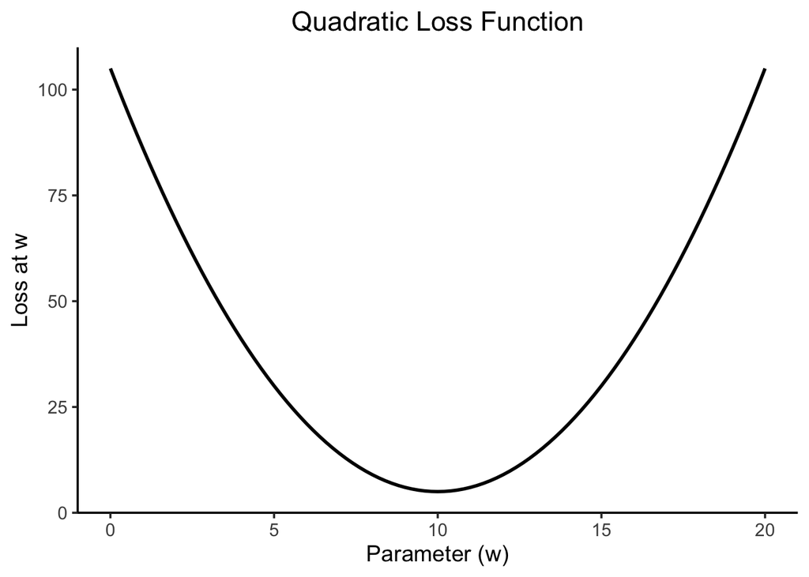

```r
library(tidyverse) |> suppressPackageStartupMessages()
loss_fn <- function(w) {
    # Make predictions using w, then sum the
    # squared residuals, how good/bad is a line
    # with slope w
    return((w - 10)^2 + 5)
}
ggplot() +
  stat_function(data=tibble(x=c(0, 10)), fun=loss_fn, linewidth=1) +
  xlim(0, 20) +
  theme_classic(base_size=14) |> center_title() +
  labs(
    title = "Quadratic Loss Function",
    x = "Parameter (w)",
    y = "Loss at w"
  )
```

## How the Derivative Helps Us

In this case, our loss function actually has an easily-computed closed-form derivative (though, as mentioned in the info box above, this is usually not the case as we move to more complex models like neural networks). We can use the chain rule $\frac{\partial}{\partial x}f(g(w)) = f'(g(w))g'(w)$ to make our lives easier, letting $f(x) = x^2 + 5$ and $g(x) = x - 10$ and recalling that $\frac{\partial}{\partial x}x^2 = 2x$:

$$L'(w) = \frac{\partial L(w)}{\partial w} = 2(w - 10)$$

The reason this matters / the reason it helps us is as follows. Recall how, in calculus class, we were able to use the derivative as a tool for finding minima and maxima of functions since **the minima and maxima of these functions are precisely the values at which the function’s derivative is zero!**

But what happens if we’re not exactly at a minimum, in this case? Calculus classes usually gloss over this question, since the answer would usually be *“Why do we care about points besides these optimal points? We can just compute the minimum and then we’re done! No need to worry about non-optimal points”*

However, when we work with more complicated models like neural networks, we don’t necessarily have an exact closed-form solution allowing us to take a derivative, set to zero, and solve. We therefore need to utilize **numerical optimization** approaches, which use the derivative as **information** telling us **which direction** we should move in and (approximately) **how much** we should move if we want to move **from** a non-optimal point **towards** the optimal point.

Let’s pick three values of $w$:

- A value **below** the minimizing value, $w_< = 5$,
- The minimizing value itself, $w_0 = 10$, and
- A value **above** the minimizing value, $w_> = 19$

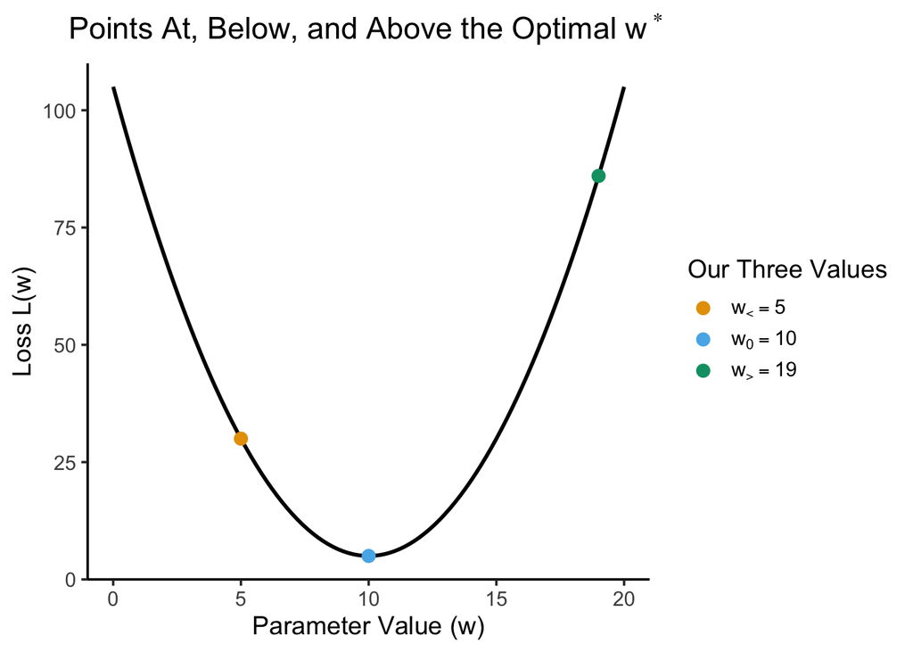

```r
library(latex2exp)
loss_deriv <- function(w) {
    return(2 * (w - 10))
}
w_vals <- c(5, 10, 19)
w_labels <- factor(c("wlt","w0","wgt"), levels=c("wlt","w0","wgt"))
data_df <- tibble(w=w_vals, label=w_labels)
data_df <- data_df |>
  mutate(
    loss = loss_fn(w),
    deriv = loss_deriv(w),
    second_deriv = 2
  )
ggplot() +
  stat_function(fun=loss_fn, linewidth=1) +
  geom_point(
    data=data_df,
    aes(x=w, y=loss, color=factor(label)),
    size=3
  ) +
  xlim(0, 20) +
  scale_color_manual(
    "Our Three Values",
    values=c("wlt"=cb_palette[1], "w0"=cb_palette[2], "wgt"=cb_palette[3]),
    labels=c("wlt"=TeX("$w_< = 5$"),"w0"=TeX("$w_0 = 10$"),"wgt"=TeX("$w_> = 19$"))
  ) +
  theme_classic(base_size=14) |> center_title() +
  labs(
    title=TeX("Points At, Below, and Above the Optimal $w^*$"),
    x = "Parameter Value (w)",
    y = "Loss L(w)"
  )
```

And let’s evaluate both the **loss function** itself (`loss`) as well as the **derivative** of the loss function (`deriv`) at each point, looking closely at what these values tell us:

```r
data_df
```

| w | label | loss | deriv | second_deriv |
| --- | --- | --- | --- | --- |
| 5 | wlt | 30 | -10 | 2 |
| 10 | w0 | 5 | 0 | 2 |
| 19 | wgt | 86 | 18 | 2 |

Here we can notice that, when we are at a value **below** the optimal value like $w_<$, the derivative has a negative sign, whereas at a value **above** the optimal value like $w_>$ the derivative has a positive sign. This relates to one of the natural interpretations of the derivative, one that your calculus class hopefully talked about, as the **slope** of the line **tangent** to the curve at that point. Adding to the previous plot of just the points, we can see this “slope interpretation” in action: while the `loss` value tells us how **high** or **low** we are on the $y$-axis here, the `deriv` value tells us how **steep** the loss function is at this point. If we adopt the convention of drawing the tangent lines (for nonzero slopes) as vectors, we get a picture that looks like:

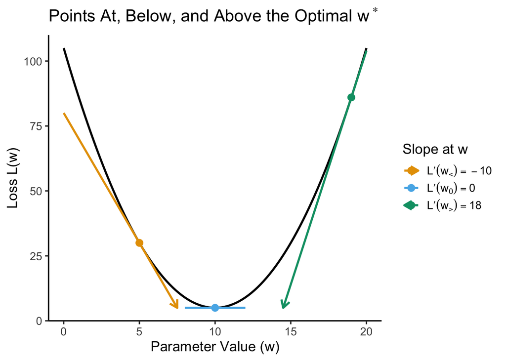

```r
tangent_at_x0 <- function(x,x0) loss_deriv(x0)*(x - x0) + loss_fn(x0)
tan_wlt <- function(x) tangent_at_x0(x, data_df$w[1])
tan_w0 <- function(x) tangent_at_x0(x, data_df$w[2])
tan_wgt <- function(x) tangent_at_x0(x, data_df$w[3])
slopes <- round(c(
  data_df$deriv[1],
  data_df$deriv[2],
  data_df$deriv[3]
), 3)
ggplot() +
  stat_function(fun=loss_fn, linewidth=1) +
  geom_function(
    fun=tan_wlt, aes(color=data_df$label[1]), linewidth=1,
    xlim=c(0,7.5), arrow = arrow(length=unit(0.30,"cm"))
  ) +
  geom_function(
    fun=tan_w0, aes(color=data_df$label[2]), linewidth=1,
    xlim=c(8,12)
  ) +
  geom_function(
    fun=tan_wgt, aes(color=data_df$label[3]), linewidth=1,
    xlim=c(14.5,20), arrow = arrow(length=unit(0.30,"cm"), ends="first")
  ) +
  geom_point(
    data=data_df,
    aes(x=w, y=loss, color=label),
    size=3
  ) +
  xlim(0, 20) +
  scale_shape_manual(
    element_blank(),
    values=19,
    labels="MLE Estimate"
  ) +
  scale_color_manual(
    "Slope at w",
    values=c("wlt"=cb_palette[1], "w0"=cb_palette[2], "wgt"=cb_palette[3]),
    labels=c("wlt"=TeX("$L'(w_<) = -10$"),"w0"=TeX("$L'(w_0) = 0$"),"wgt"=TeX("$L'(w_>) = 18$"))
  ) +
  theme_classic(base_size=14) |> center_title() +
  labs(
    title=TeX("Points At, Below, and Above the Optimal $w^*$"),
    x = "Parameter Value (w)",
    y = "Loss L(w)"
  )
```

And this shows us exactly why computing the derivative at a point **away from** the optimal value still helps us when it comes to numerical optimization, in two ways:

- First, the derivative at these points (literally) **points us** in the direction we should go in if we want to move towards the optimal value.
- Then (though I’ll stop after this and let you see the effect of this point by going through the assignment’s different parts, since it relates to the **second** derivative rather than the first), notice also how the monotonicity properties of the quadratic function $f(x) = x^2$ also tells us **“how wrong” we are**, in a sense:
  - $w_> = 19$ is **further away from** the optimal point than $w_< = 5$, therefore
  - The **magnitude** of the derivative at $w_>$ (18) is greater than the **magnitude** of the derivative at $w_<$ (10).

Like I mentioned, I’m stopping here since the later portions of the assignment dive into the information that the **second derivative** at a point can provide for our numerical optimizer, but to test your understanding you can imagine writing a third section here titled **“How The (Second) Derivative Helps Us”**.

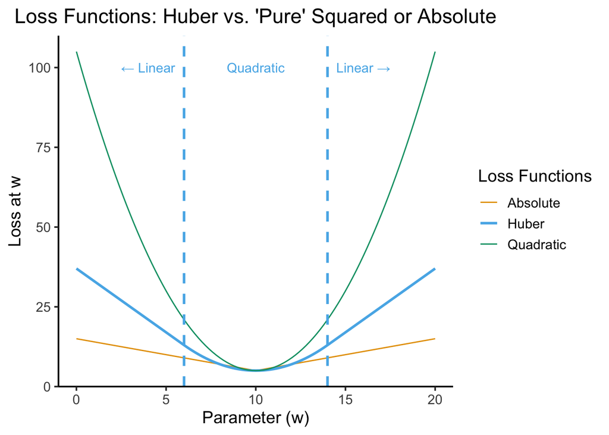

```r
abs_loss <- function(w) {
  return(abs(w - 10) + 5)
}
delta <- 4
huberized_loss <- function(w) {
  cases_result <- ifelse(
    abs(w - 10) <= delta,
    (1/2)*(w - 10)^2,
    delta * (abs(w-10) - (1/2)*delta)
  )
  return(cases_result + 5)
}
text_df <- tibble::tribble(
  ~x, ~y, ~label,
  4, 100, "← Linear",
  10, 100, "Quadratic",
  16, 100, "Linear →"
)
ggplot() +
  stat_function(
    data=tibble(x=c(0, 10)),
    fun=abs_loss,
    aes(color='Absolute'),
    linewidth=0.5
  ) +
  stat_function(
    data=tibble(x=c(0, 10)),
    fun=huberized_loss,
    aes(color='Huber'),
    linewidth=1
  ) +
  stat_function(
    data=tibble(x=c(0,10)),
    fun=loss_fn,
    aes(color='Quadratic'),
    linewidth=0.5
  ) +
  geom_vline(
    xintercept=10 - delta,
    linetype="dashed",
    linewidth=1,
    color=cb_palette[2]
  ) +
  geom_vline(
    xintercept=10+delta,
    linetype="dashed",
    linewidth=1,
    color=cb_palette[2]
  ) +
  geom_text(
    data=text_df,
    aes(x=x, y=y, label=label),
    color=cb_palette[2]
  ) +
  xlim(0, 20) +
  theme_classic(base_size=14) |> center_title() +
  scale_color_manual(
    "Loss Functions",
    values=c('Absolute'=cb_palette[1], 'Huber'=cb_palette[2], 'Quadratic'=cb_palette[3])
    #labels=c('Absolute', 'Huber', 'Quadratic')
  ) +
  labs(
    title = "Loss Functions: Huber vs. 'Pure' Squared or Absolute",
    x = "Parameter (w)",
    y = "Loss at w"
  )
```